# Theory figures: deemed-optimal policy and credibility

Predictions for the paper figures on policy support and sender credibility

# 1 Setup

$\alpha$ is the probability that evidence continues to deem the same policy optimal. Underlying optimality does not change. $1-\alpha$ is the probability that new evidence leads a different policy to be *deemed* optimal. $p$ is the prior that period-1 evidence deems policy 1 optimal. $q$ is prior confidence that the sender is competent.

```r
if (!requireNamespace("pacman", quietly = TRUE)) install.packages("pacman")
pacman::p_load(
  tidyverse,
  gridExtra,
  knitr,
  latex2exp
)

fig_dir <- "2_figures"
dir.create(fig_dir, showWarnings = FALSE)
```

Citizens have a prior $p$ that period-1 evidence deems policy 1 optimal. With probability $\alpha$, new evidence continues to deem the same policy optimal; with probability $1-\alpha$, new evidence leads the other policy to be deemed optimal. True optimality is fixed; only the evidence-implied (deemed) recommendation may change.

Beliefs over the deemed-optimal path $(w_1, w_2)$ are

$$\begin{align*}
p_{11} &= p\alpha\\
p_{10} &= p(1-\alpha) \\
p_{01} &= (1-p)(1-\alpha) \\
p_{00} &= (1-p)\alpha
\end{align*}$$

Without loss of generality the first signal is for policy 1.

| Event $(w_1, w_2, \theta)$ | Prior | $\Pr(s_1 = 1, s_2=1)$ | $\Pr(s_1 = 1, s_2=0)$ |
| --- | --- | --- | --- |
| (0, 0, 0) | $p_{00}(1-q)$ | $(1-r)^2$ | $r(1-r)$ |
| (0, 1, 0) | $p_{01}(1-q)$ | $r(1-r)$ | $(1-r)^2$ |
| (1, 0, 0) | $p_{10}(1-q)$ | $r(1-r)$ | $r^2$ |
| (1, 1, 0) | $p_{11}(1-q)$ | $r^2$ | $r(1-r)$ |
| (0, 0, 1) | $p_{00}q$ | $0$ | $0$ |
| (0, 1, 1) | $p_{01}q$ | $0$ | $0$ |
| (1, 0, 1) | $p_{10}q$ | $0$ | $1$ |
| (1, 1, 1) | $p_{11}q$ | $1$ | $0$ |

Posterior on capacity after a consistent signal $(1,1)$:

$$p^c_{11} = \frac{p_{11} q}{p_{11}q + (p_{00}(1-r)^2 + (p_{01}+p_{10})r(1-r) + p_{11} r^2)(1-q)}$$

and after an inconsistent signal $(1,0)$:

$$p^c_{10} = \frac{p_{10} q}{p_{10} q + ((p_{00}+p_{11})r(1-r) + p_{01}(1-r)^2 + p_{10}r^2)(1-q)}$$

$p^c_{10} \leq p^c_{11}$ iff $\alpha \geq 0.5$: inconsistency is more damaging when evidence is expected to keep deeming the same policy optimal.

Posterior confidence that policy 1 is deemed optimal in period 2, given messages:

$$p^1_{11} = \frac{p_{11} q + (p_{01}r(1-r)+p_{11}r^2)(1-q)}{p_{11}q + (p_{00}(1-r)^2 + (p_{01}+ p_{10})r(1-r) + p_{11} r^2)(1-q)}$$

$$p^1_{10} = \frac{(r(1-r)p_{11} + (1-r)^2p_{01})(1-q)}{p_{10} q + ((p_{00}+p_{11})r(1-r) + p_{01}(1-r)^2 + p_{10}r^2)(1-q)}$$

# 2 Helpers

```r
# α = P(deemed-optimal policy persists as evidence accumulates)
p_11 <- function(p, a) p * a
p_10 <- function(p, a) p * (1 - a)
p_01 <- function(p, a) (1 - p) * (1 - a)
p_00 <- function(p, a) (1 - p) * a

p_c_11 <- function(p, a, q, r) {
  num <- p_11(p, a) * q
  denom <- p_11(p, a) * q +
    (p_00(p, a) * (1 - r)^2 + (p_01(p, a) + p_10(p, a)) * r * (1 - r) +
       p_11(p, a) * r^2) * (1 - q)
  num / denom
}

p_c_10 <- function(p, a, q, r) {
  num <- p_10(p, a) * q
  denom <- p_10(p, a) * q +
    ((p_00(p, a) + p_11(p, a)) * r * (1 - r) + p_01(p, a) * (1 - r)^2 +
       p_10(p, a) * r^2) * (1 - q)
  num / denom
}

p_c_01 <- function(p, a, q, r) {
  num <- p_01(p, a) * q
  denom <- p_01(p, a) * q +
    ((p_00(p, a) + p_11(p, a)) * r * (1 - r) + p_01(p, a) * r^2 +
       p_10(p, a) * (1 - r)^2) * (1 - q)
  num / denom
}

p_c_00 <- function(p, a, q, r) {
  num <- p_00(p, a) * q
  denom <- p_00(p, a) * q +
    (p_00(p, a) * r^2 + (p_01(p, a) + p_10(p, a)) * r * (1 - r) +
       p_11(p, a) * (1 - r)^2) * (1 - q)
  num / denom
}

p_1_11 <- function(p, a, q, r) {
  num <- p_11(p, a) * q +
    (p_01(p, a) * r * (1 - r) + p_11(p, a) * r^2) * (1 - q)
  denom <- p_11(p, a) * q +
    (p_00(p, a) * (1 - r)^2 + (p_01(p, a) + p_10(p, a)) * r * (1 - r) +
       p_11(p, a) * r^2) * (1 - q)
  num / denom
}

p_1_10 <- function(p, a, q, r) {
  num <- (r * (1 - r) * p_11(p, a) + (1 - r)^2 * p_01(p, a)) * (1 - q)
  denom <- p_10(p, a) * q +
    ((p_00(p, a) + p_11(p, a)) * r * (1 - r) + p_01(p, a) * (1 - r)^2 +
       p_10(p, a) * r^2) * (1 - q)
  num / denom
}

p_1_01 <- function(p, a, q, r) {
  num <- p_01(p, a) * q +
    (r * (1 - r) * p_11(p, a) + r^2 * p_01(p, a)) * (1 - q)
  denom <- p_01(p, a) * q +
    ((p_00(p, a) + p_11(p, a)) * r * (1 - r) + p_01(p, a) * r^2 +
       p_10(p, a) * (1 - r)^2) * (1 - q)
  num / denom
}

p_1_00 <- function(p, a, q, r) {
  num <- (p_01(p, a) * r * (1 - r) + p_11(p, a) * (1 - r)^2) * (1 - q)
  denom <- p_00(p, a) * q +
    (p_00(p, a) * r^2 + (p_01(p, a) + p_10(p, a)) * r * (1 - r) +
       p_11(p, a) * (1 - r)^2) * (1 - q)
  num / denom
}

alpha_lab <- function(a) {
  latex2exp::TeX(paste0("$\\alpha = ", a, "$ (deemed optimum persists)"))
}
```

# 3 Predictions

```r
df2 <- expand_grid(
  p = c(.05, .25, .5, .75, .95),
  a = c(.51, .625, .75, .875, .95),
  q = seq(.01, .99, length = 25),
  r = 2 / 3
) |>
  mutate(
    p00 = p_00(p, a),
    p01 = p_01(p, a),
    p10 = p_10(p, a),
    p11 = p_11(p, a),
    c_11 = p_c_11(p, a, q, r),
    c_10 = p_c_10(p, a, q, r),
    c_01 = p_c_01(p, a, q, r),
    c_00 = p_c_00(p, a, q, r),
    d_c = c_10 - c_11,
    pol_1_11 = p_1_11(p, a, q, r),
    pol_1_10 = p_1_10(p, a, q, r),
    pol_1_01 = p_1_01(p, a, q, r),
    pol_1_00 = p_1_00(p, a, q, r),
    d_pol_1 = pol_1_10 - pol_1_11,
    d_pol_2 = pol_1_01 - pol_1_11
  )
```

Inconsistency lowers credibility. The penalty is larger when $\alpha$ is high (new evidence is expected to keep deeming the same policy optimal) and when $q$ is middling.

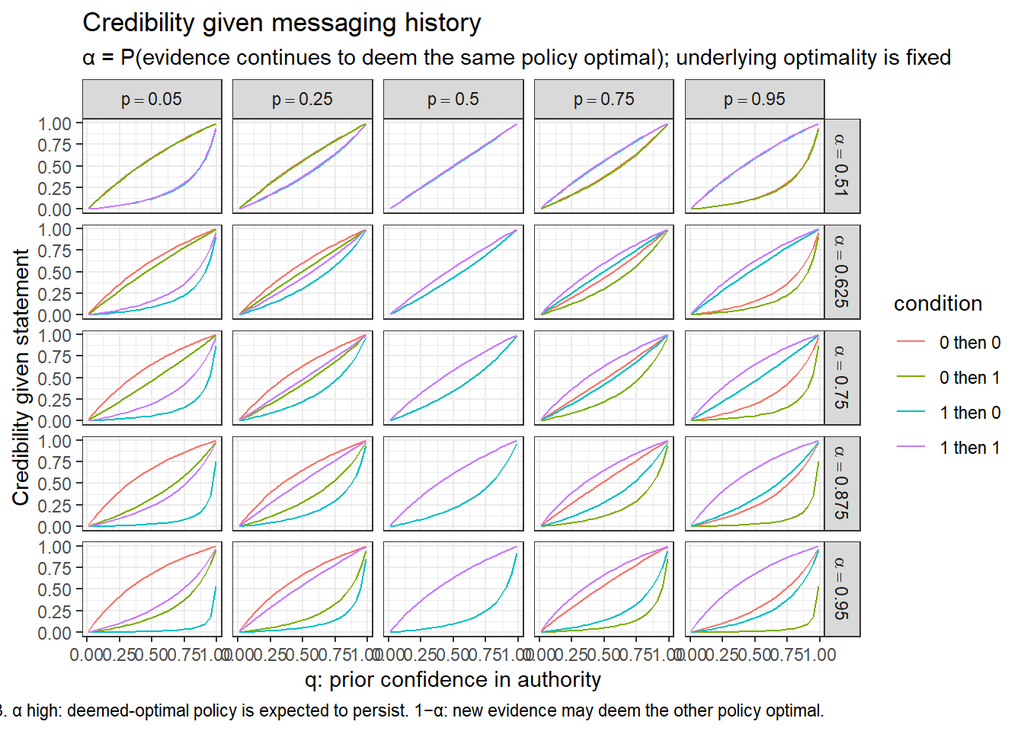

Figure 1

```r
fig_credibility <-
  df2 |>
  select(p, a, q, r, c_11, c_10, c_01, c_00) |>
  pivot_longer(c(c_11, c_10, c_01, c_00), names_to = "condition", values_to = "val") |>
  mutate(
    condition = factor(
      condition,
      c("c_00", "c_01", "c_10", "c_11"),
      c("0 then 0", "0 then 1", "1 then 0", "1 then 1")
    ),
    a = factor(a, unique(a), latex2exp::TeX(paste0("$\\alpha = ", unique(a), "$"))),
    p = factor(p, unique(p), latex2exp::TeX(paste0("$p = ", unique(p), "$")))
  ) |>
  ggplot(aes(q, val, color = condition)) +
  geom_line() +
  facet_grid(a ~ p, labeller = label_parsed) +
  ylab("Credibility given statement") +
  xlab("q: prior confidence in authority") +
  ggtitle("Credibility given messaging history") +
  labs(
    subtitle = "α = P(evidence continues to deem the same policy optimal); underlying optimality is fixed",
    caption = "r = 2/3. α high: deemed-optimal policy is expected to persist. 1−α: new evidence may deem the other policy optimal."
  ) +
  theme_bw() +
  scale_x_continuous(breaks = seq(0, 1, by = 0.25))

fig_credibility
```

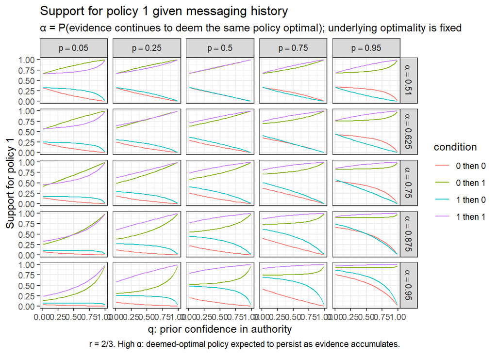

Figure 2

```r
fig_policy <-
  df2 |>
  select(p, a, q, r, pol_1_11, pol_1_10, pol_1_01, pol_1_00) |>
  pivot_longer(
    c(pol_1_11, pol_1_10, pol_1_01, pol_1_00),
    names_to = "condition",
    values_to = "val"
  ) |>
  mutate(
    condition = factor(
      condition,
      c("pol_1_00", "pol_1_01", "pol_1_10", "pol_1_11"),
      c("0 then 0", "0 then 1", "1 then 0", "1 then 1")
    ),
    a = factor(a, unique(a), latex2exp::TeX(paste0("$\\alpha = ", unique(a), "$"))),
    p = factor(p, unique(p), latex2exp::TeX(paste0("$p = ", unique(p), "$")))
  ) |>
  ggplot(aes(q, val, color = condition)) +
  geom_line() +
  facet_grid(a ~ p, labeller = label_parsed) +
  ylab("Support for policy 1") +
  xlab("q: prior confidence in authority") +
  ggtitle("Support for policy 1 given messaging history") +
  labs(
    subtitle = "α = P(evidence continues to deem the same policy optimal); underlying optimality is fixed",
    caption = "r = 2/3. High α: deemed-optimal policy expected to persist as evidence accumulates."
  ) +
  theme_bw() +
  scale_x_continuous(breaks = seq(0, 1, by = 0.25))

fig_policy
```

# 4 Export

```r
ggsave(
  file.path(fig_dir, "credibility.pdf"),
  fig_credibility,
  width = 10,
  height = 6
)

ggsave(
  file.path(fig_dir, "policy.pdf"),
  fig_policy,
  width = 10,
  height = 6
)
```